# 3.2 — Market Competition and Surpluses — Practice Problems

Solutions

ECON 306 — Fall 2022

The supply and demand in the market for tomatoes are estimated to be:
$$\begin{aligned}
q_D&=1000-200p\\
q_S&=200p-200\\ \end{aligned}$$

### 1. Calculate the market-clearing price and quantity exchanged.

$$\begin{align*}
q_D&=q_S && \text{Definition of equilibrium}\\
1000-200p&=200p-200 && \text{Plugging in demand and
supply functions}\\
1000&=400p-200 && \text{Adding } 200p \text{ to both
sides}\\
1200&=400p && \text{Adding } 200 \text{ to both sides}\\
3&=p^* && \text{Dividing both sides by }400\\
\end{align*}$$

Now finding equilibrium quantity, q* using Demand:

$$\begin{align*}
q_D&=1000-200p && \text{The demand function}\\
q_D&=1000-200(3) && \text{Plugging in } p^*=3 \\
q_D&=1000-600 && \text{Multiplying}\\
q^*&=400 && \text{Subtracting}\\
\end{align*}$$

### 2. Find the inverse demand function and inverse supply function.

First, demand:

$$\begin{align*}
q_D&=1000-200p && \text{The demand function}\\
q_D+200p&=1000 && \text{Adding }200p \text{ to both
sides}\\
200p&=1000-q_D && \text{Subtracting }q_D \text{ from
both sides}\\
p&=5-0.005q_D && \text{Dividing both sides by }200\\
\end{align*}$$

The demand choke price is $5 and the slope is $-0.005$ (or $-\frac{1}{200}$)

Then supply:

$$\begin{align*}
q_S&=200p-200 && \text{The supply function}\\
q_S+200&=200p && \text{Adding 200 to both sides}\\
0.005q_S+1&=p && \text{Dividing both sides by 200}\\
\end{align*}$$

The supply choke price is $1 and the slope is 0.005 (or $\frac{1}{200}$)

### 3.Sketch a graph of this market, labelling key points.

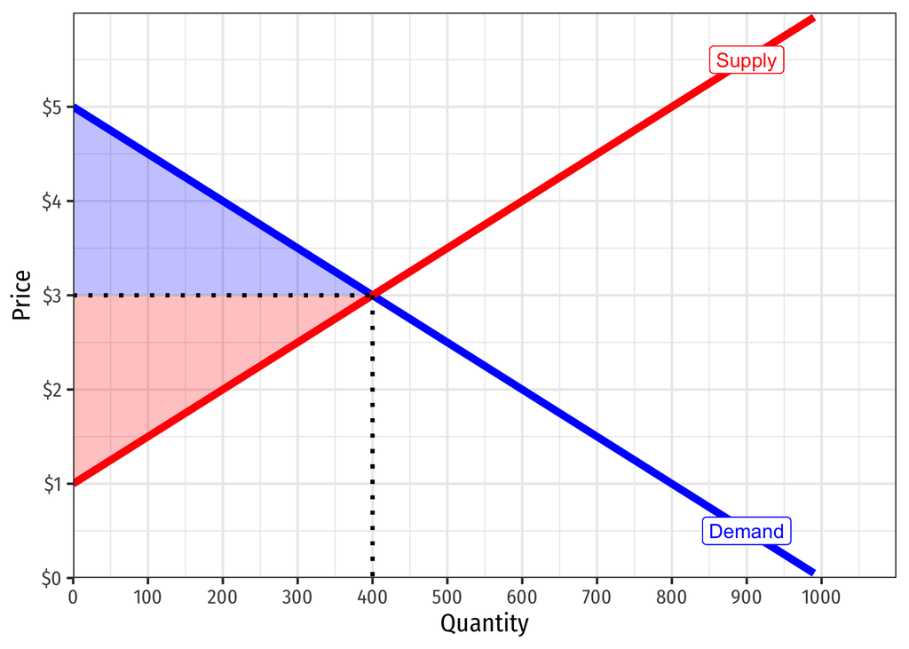

### 4. Calculate the price elasticty of demand and price elasticity of supply (in equilibrium).

First, demand:

$$\begin{aligned}
E&=\frac{1}{slope}\times \frac{p}{q}\\
E&=\frac{1}{(-0.005)} \times \frac{3}{400}\\
E&=-200 \times 0.0075\\
E&=-1.5\\
\end{aligned}$$

Demand is relatively elastic. For every 1% increase (decrease) in price, consumers will buy 1.5% less (more).

Next, supply:

$$\begin{aligned}
E&=\frac{1}{slope}\times \frac{p}{q}\\
E&=\frac{1}{(0.005)} \times \frac{3}{400}\\
E&=200 \times 0.0075\\
E&=1.5\\
\end{aligned}$$

Supply is relatively elastic. For every 1% increase (decrease) in price, producers will well 1.5% more (less).

Notice that demand and supply have the *same* price elasticity in equilibrium (at least in terms of magnitude, for demand it will always be negative)! The price and quantity is the same for both curves (by definition, that’s equilibrium), but in this case the slopes are the same - so the elasticities will be the same. This shows you slope has a strong effect on elasticity.

### 5. Calculate the consumer surplus and producer surplus, and shade each on the graph.

Consumer surplus is a triangle (shaded in blue) between the demand curve (most consumers are willing to pay) and the market price (what they actually pay). The area of the triangle is:

$$\begin{aligned}
CS &=\frac{1}{2}bh\\
CS &=\frac{1}{2}(400-0)(\$5-\$3)\\
CS &=\frac{1}{2}(400)(2)\\
CS &=\frac{1}{2}800\\
CS &=400\\
\end{aligned}$$

Producer surplus is a triangle (shaded in red) between the market price (what sellers actually recieve) and the supply curve (the lowest they would be willing to recieve). The area of the triangle is:

$$\begin{aligned}
PS &=\frac{1}{2}bh\\
PS &=\frac{1}{2}(400-0)(\$3-\$1)\\
PS &=\frac{1}{2}(400)(2)\\
PS &=\frac{1}{2}800\\
PS &=400\\
\end{aligned}$$

### 6. Who gets greater surplus, consumers or producers, and why?

In this case, because both supply and demand have the same elasticity in equilibrium, they earn the same amount of surplus.